# W_UP_01

Kiara Butler

fall 2023

# Introduction

Create an Rstudio project in your shared space on rstudio.cloud. Using the dataset called pushups from the tigerstats package in R; answer the question posed by this null and alternate hypothesis in an html markdown document.

$H_0$: There is no difference between the average number of pushups of line vs skill players

$H_A$: The average number of pushups done by line players is statistically different than that of skill players.

# Results

## Descriptive Results

### Graphical Descriptive Results

### Plot boxplots

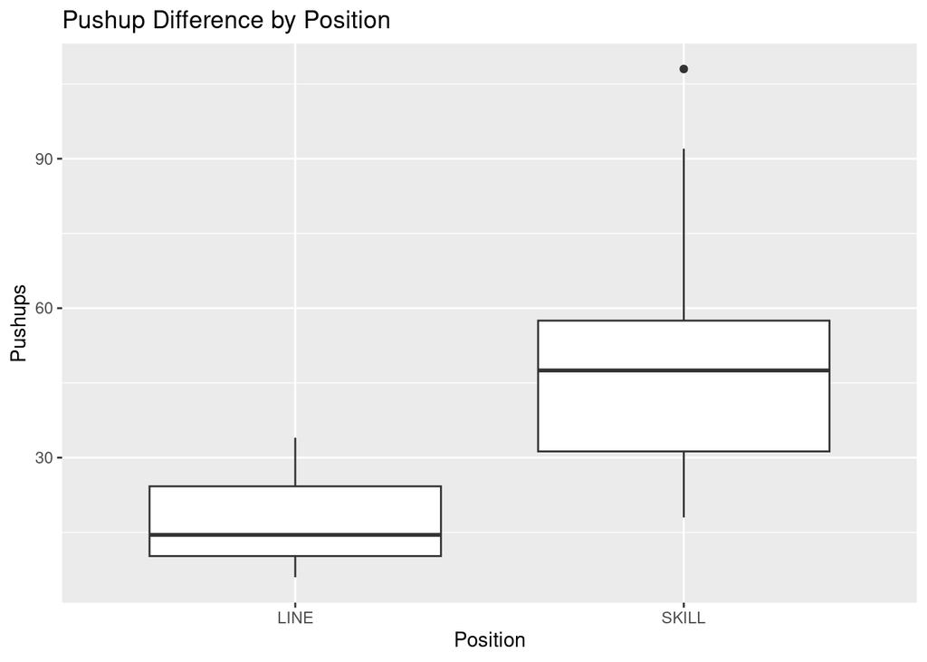

```r
ggplot(mydata, aes(x = position, y = pushups)) +
  geom_boxplot() +
  labs(
    title = "Pushup Difference by Position",
    x = "Position",
    y = "Pushups"
  )
```

I’m looking at the columns in the chart above, the left are the line position, and on the right are skilled position

the right are the skilled box is much higher.

the 25th percentile on the skilled player is higher than 75th percentile of the line player

this seems to indicate that skilled position can do more push-ups than line position

### Numerical Descriptive Results

```r
favstats(pushups~ position,data=mydata)
```

```
##   position min    Q1 median    Q3 max     mean        sd  n missing
## 1     LINE   6 10.25   14.5 24.25  34 17.12500  9.745878  8       0
## 2    SKILL  18 31.25   47.5 57.50 108 49.72727 23.036579 22       0
```

A line player can do the average number push-ups, which is about one-third the amount of an average skilled player.

## Inferential Results

```r
t.test(pushups~ position,data=mydata)
```

```
##
##  Welch Two Sample t-test
##
## data:  pushups by position
## t = -5.4341, df = 27.079, p-value = 9.421e-06
## alternative hypothesis: true difference in means between group LINE and group SKILL is not equal to 0
## 95 percent confidence interval:
##  -44.91068 -20.29387
## sample estimates:
##  mean in group LINE mean in group SKILL
##            17.12500            49.72727
```

the p-value is for smaller that 0.05 indicated that there is a strong statistical significance.  
this rejects the $H_O$ leaving only the $H_A$.

# Discussion and Conclusion

$H_0$ = there is no difference in push-ups based on position $H_A$ = there is a difference in push-ups based on position

with assistance from ChatGPT I was able to write some R code to create a box plot

Also, by using the numerical-chat tool I was able to perform a T test and A summary of the Data (favstats).

The box plot in conjunction with with the summary and T test Show what we can reject the $H_0$ leaving only the $H_A$.